# Human Activity Recognition: Weight Lifting Execution Predictive Model

J2

May 8, 2016

# Introduction

Human activity recognition research has traditionally focused on discriminating between different activities, i.e. to predict “which” activity was performed at a specific point in time. Research conducted by Velloso, Bulling, Gellersen, Ugulino, and Fuks investigated the degree to which qualitative activity recognition could detect “how (well)” an activity was performed.

Six young health participants were asked to perform one set of 10 repetitions of the Unilateral Dumbbell Biceps Curl (UDBC) in five different fashions: exactly according to the specification (Class A), throwing the elbows to the front (Class B), lifting the dumbbell only halfway (Class C), lowering the dumbbell only halfway (Class D) and throwing the hips to the front (Class E). Class A corresponds to the specified execution of the exercise, while the other 4 classes correspond to common mistakes.[1]

Sensors mounted in the users’ glove, armband, lumbar belt and dumbbell connected to inertial measurement units (IMU) provided three-axes acceleration, gyroscope and magnetometer data.

The purpose of this project is to develop a predictive model that interprets the data and correctly classifies the participants’ execution of the dumbbell curl into one of the 5 classes.

# Study Design and Cross Validation

The dataset, provided courtesy of Velloso, Bulling, Gellersen, Ugulino, and Fuks, is available on the Human Activity Recognition Project webpage on the Groupware@LES website. It was downloaded below.

```r
trainUrl   <- "https://d396qusza40orc.cloudfront.net/predmachlearn/pml-training.csv"
testUrl    <- "https://d396qusza40orc.cloudfront.net/predmachlearn/pml-testing.csv"

download.file(trainUrl, destfile = "trainFile.csv")
download.file(testUrl, destfile = "testFile.csv")

trainFile  <- read.csv("trainFile.csv", na.strings=c('#DIV/0', '', 'NA'))
testFile   <- read.csv("testFile.csv", na.strings=c('#DIV/0', '', 'NA'))
```

The test set was set aside and designated “validation set” for the purposes of this study. A random sampling of 70% of The training data set was designated for training and the remaining 30% was set aside for testing purposes.

```r
library(caret)
set.seed(1030)
inTrain       <- createDataPartition(y=trainFile$classe, p=0.70, list = FALSE)
trainData     <- trainFile[inTrain,]      #Training Data
testData      <- trainFile[-inTrain,]     #Testing Data
valData       <- testFile                 #Validation Data
```

Models were trained on the training data using 10-fold repeated cross-validation, repeated 3 times. Selected prediction models were then evaluated on the test data set. The best performing prediction model was then applied to the validation set for final submission.

# Data Analysis

The following code extracts select summary data on the new training set.

```r
library(funModeling)

#Gather basic dimensions
observations <- dim(trainData)[1]
variables    <- dim(trainData)[2]

#Summarize zeros, NAs, data type, and number of unique values
trainDataStatus <- df_status(trainData)
naVars      <- subset(trainDataStatus, trainDataStatus$p_na > 80)
minNaVars   <- min(naVars$q_na)
pctNaVars   <- min(naVars$p_na)
numNaVars   <- nrow(naVars)
```

Of particular note was that there were 100 variables that contained a minimum of 13461 (97.99 %) NA values across all observations in the training set.

# Data PreProcessing

Standardization of variables is a common requirement for many machine learning classifiers. Non-predictor and variables with high NA values were removed and the remaining predictor variables in test, training and validation sets were centered and scaled. The test and validation sets were centered and scaled based upon the mean and standard deviations from the training set.

```r
library(funModeling)
library(caret)
#Select non-predictor (NP) variables that should be excluded from centering and scaling
nonPredictors <- c("X", "user_name", "raw_timestamp_part_1",
                   "raw_timestamp_part_2", "cvtd_timestamp",
                   "new_window", "num_window")

#Remove non-predictors from data sets
trainDataCS   <- trainData[, -which(names(trainData) %in% nonPredictors)]
testDataCS    <- testData[, -which(names(testData) %in% nonPredictors)]
valDataCS     <- valData[, -which(names(valData) %in% nonPredictors)]

#Center and scale independent variables based upon means from training set.
centerScale   <- preProcess(trainDataCS, method=c("center", "scale"))
trainDataCS   <- predict(centerScale, trainDataCS[-153])
testDataCS    <- predict(centerScale, testDataCS[-153])
valDataCS     <- predict(centerScale, valDataCS[-153])

#Add outcome variable back to data sets
trainDataCS   <- data.frame(trainDataCS,classe=trainData$classe)
testDataCS    <- data.frame(testDataCS,classe=testData$classe)
valDataCS     <- data.frame(valDataCS,problem_id=valData$problem_id)
```

Next, the variables which contained over 80% NA values over the training set were identified. Those variables were then removed from the training, test, and validation sets.

```r
#Identify columns in the training set with over 80% NA values
trainDataCSStatus <- df_status(trainDataCS)
naVars      <- subset(trainDataCSStatus, trainDataCSStatus$p_na > 80)

#Remove them from training, test and validation sets
trainDataCS <- trainDataCS[, !(names(trainDataCS) %in% naVars[,"variable"])]
testDataCS  <- testDataCS[, !(names(testDataCS) %in% naVars[,"variable"])]
valDataCS   <- valDataCS[, !(names(valDataCS) %in% naVars[,"variable"])]

#Summarize dimensions of training set
trainObservations  <- nrow(trainDataCS)
trainVariables     <- ncol(trainDataCS)
```

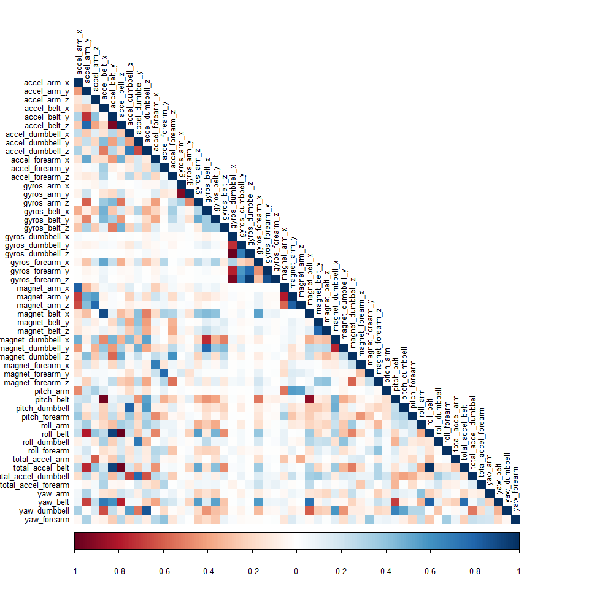

```r
#Render correlation plot
library(corrplot)
corMatrix <- cor(trainDataCS[-53])
corrplot::corrplot(corMatrix, order = "alphabet", method = "color", type = "lower",
          tl.cex = 0.8, tl.col = rgb(0, 0, 0))
```

Figure 1: Correlation Matrix

The data among the belt measurements show some correlation, as do the data among the dumbbell measurements. Given the nature of the movements among the sensors, this would be expected. That said, the independent variables were by and large independent.

# Model Selection

An ensemble learning approach was pursued, and as such, a diversity of models was evaluated. A base set of 28 models were selected from 10 categories. The code used to train these models can be found in the appendix (Code 1). **Ensemble 1** was comprised of the models from the base set, with the exception of rda, parRF, mlp, J48, and JRip, which were not included due to performance and technical constraints. **Ensemble 2** was comprised of the best performing models from the base set. The best of all models evaluated was then applied to the validation set for final evaluation and submission.

## Base Models

The following table summarizes the base models selected and their performance. Models included in the two ensemble models are designated as such.

Table 2: Model Selection and Performance

| Num | Category | Model | Method | Ensemble 1 | Ensemble 2 | Accuracy | Kappa |
| --- | --- | --- | --- | --- | --- | --- | --- |
| 1 | Bayesian Methods | Naive Bayes | nb | *** |  | 0.7398 | 0.6675 |
| 2 | Boosting Methods | AdaBoost.M1 | AdaBoost.M1 | *** | *** | 0.9327 | 0.9150 |
| 3 | Boosting Methods | Stochastic Gradient Boosting | gbm | *** | *** | 0.9614 | 0.9512 |
| 4 | Boosting Methods | eXtreme Gradient Boosting | xgbTree | *** | *** | 0.9939 | 0.9922 |
| 5 | Partial Least Squares | Partial Least Squares | pls | *** |  | 0.3780 | 0.1930 |
| 6 | Partial Least Squares | Partial Least Squares | simpls | *** |  | 0.3780 | 0.1930 |
| 7 | Partial Least Squares | Partial Least Squares | widekernelpls | *** |  | 0.3780 | 0.1930 |
| 8 | Discriminant Analysis | Flexible Discriminant Analysis | fda | *** |  | 0.6942 | 0.6147 |
| 9 | Discriminant Analysis | Mixture Discriminant Analysis | mda | *** |  | 0.7422 | 0.6746 |
| 10 | Discriminant Analysis | Robust Quadratic Discriminant Analysis | QdaCov | *** |  | 0.5862 | 0.4845 |
| 11 | Discriminant Analysis | Penalized Discriminant Analysis | pda | *** |  | 0.7016 | 0.6223 |
| 12 | Discriminant Analysis | Regularized Discriminant Analysis | rda |  |  | 0.8938 | 0.8658 |
| 13 | Bagged Methods | Bagged CART | treebag | *** | *** | 0.9864 | 0.9828 |
| 14 | Ensemble | Parallel Random Forest | parRF |  |  | 0.9923 | 0.9903 |
| 15 | Ensemble | Random Forest | rf | *** | *** | 0.9921 | 0.9900 |
| 16 | Ensemble | Regularized Random Forest | RRF | *** | *** | 0.9647 | 0.9554 |
| 17 | Ensemble | Weighted Subspace Random Forest | wsrf | *** | *** | 0.9921 | 0.9901 |
| 18 | Instance Based | k-Nearest Neighbors | knn | *** | *** | 0.9595 | 0.9488 |
| 19 | Neural Network | Model Averaged Neural Network | avNNet | *** |  | 0.7844 | 0.7260 |
| 20 | Neural Network | Multi-Layer Perceptron | mlp |  |  | 0.7736 | 0.7131 |
| 21 | Regression | Multivariate Adaptive Regression Splines | gcvEarth | *** |  | 0.7614 | 0.6978 |
| 22 | Regression | Penalized Multinomial Regression | multinom | *** |  | 0.7337 | 0.6623 |
| 23 | Decision Trees | C5.0 | C5.0 | *** | *** | 0.9945 | 0.9931 |
| 24 | Decision Trees | Single C5.0 Tree | C5.0Tree | *** | *** | 0.9573 | 0.9460 |
| 25 | Decision Trees | Conditional Inference Tree | ctree | *** |  | 0.8819 | 0.8505 |
| 26 | Decision Trees | C4.5-like Trees | J48 |  |  | 0.9539 | 0.9417 |
| 27 | Decision Trees | Rule-Based Classifier | JRip |  |  | 0.9453 | 0.9308 |
| 28 | Decision Trees | CART | rpart | *** |  | 0.5250 | 0.3860 |

## Ensemble 1

The following code prepares and executes ensemble 1 on the test set.

```r
pred.nb <-  predict(model.nb,testDataCS)
pred.AdaBoost.M1    <-  predict(model.AdaBoost.M1,testDataCS)
pred.gbm    <-  predict(model.gbm,testDataCS)
pred.xgbTree    <-  predict(model.xgbTree,testDataCS)
pred.pls    <-  predict(model.pls,testDataCS)
pred.simpls <-  predict(model.simpls,testDataCS)
pred.widekernelpls  <-  predict(model.widekernelpls,testDataCS)
pred.fda    <-  predict(model.fda,testDataCS)
pred.mda    <-  predict(model.mda,testDataCS)
pred.QdaCov <-  predict(model.QdaCov,testDataCS)
pred.pda    <-  predict(model.pda,testDataCS)
pred.treebag    <-  predict(model.treebag,testDataCS)
pred.rf <-  predict(model.rf,testDataCS)
pred.RRF    <-  predict(model.RRF,testDataCS)
pred.wsrf   <-  predict(model.wsrf,testDataCS)
pred.knn    <-  predict(model.knn,testDataCS)
pred.avNNet <-  predict(model.avNNet,testDataCS)
pred.gcvEarth   <-  predict(model.gcvEarth,testDataCS)
pred.multinom   <-  predict(model.multinom,testDataCS)
pred.C5.0   <-  predict(model.C5.0,testDataCS)
pred.C5.0Tree   <-  predict(model.C5.0Tree,testDataCS)
pred.ctree  <-  predict(model.ctree,testDataCS)
pred.rpart  <-  predict(model.rpart,testDataCS)

#Combine all predictors into data frame.
pred.DF <- data.frame(pred.nb,
                       pred.AdaBoost.M1,
                       pred.gbm,
                       pred.xgbTree,
                       pred.pls,
                       pred.simpls,
                       pred.widekernelpls,
                       pred.fda,
                       pred.mda,
                       pred.QdaCov,
                       pred.pda,
                       pred.treebag,
                       pred.rf,
                       pred.RRF,
                       pred.wsrf,
                       pred.knn,
                       pred.avNNet,
                       pred.gcvEarth,
                       pred.multinom,
                       pred.C5.0,
                       pred.C5.0Tree,
                       pred.ctree,
                       pred.rpart, classe = testDataCS$classe)

#Train all predictors
set.seed(1030)
model.ensemble1 <- train(classe~., data=pred.DF, trControl=ctrl, method="rf")
```

This ensemble had an accuracy of **0.99473** and a kappa value of **0.99334**. The following summarizes the ensemble performance.

```r
model.ensemble1$finalModel
```

```
##
## Call:
##  randomForest(x = x, y = y, mtry = param$mtry)
##                Type of random forest: classification
##                      Number of trees: 500
## No. of variables tried at each split: 47
##
##         OOB estimate of  error rate: 0.53%
## Confusion matrix:
##      A    B    C   D    E  class.error
## A 1670    4    0   0    0 0.0023894863
## B    4 1131    4   0    0 0.0070237050
## C    0    4 1015   7    0 0.0107212476
## D    0    0    7 957    0 0.0072614108
## E    0    0    0   1 1081 0.0009242144
```

## Ensemble 2

The following code prepares and executes ensemble 2 on the test set.

```r
#Predict Best models
pred.AdaBoost.M1    <-  predict(model.AdaBoost.M1,testDataCS)
pred.gbm    <-  predict(model.gbm,testDataCS)
pred.xgbTree    <-  predict(model.xgbTree,testDataCS)
pred.treebag    <-  predict(model.treebag,testDataCS)
pred.rf <-  predict(model.rf,testDataCS)
pred.RRF    <-  predict(model.RRF,testDataCS)
pred.wsrf   <-  predict(model.wsrf,testDataCS)
pred.knn    <-  predict(model.knn,testDataCS)
pred.C5.0   <-  predict(model.C5.0,testDataCS)
pred.C5.0Tree   <-  predict(model.C5.0Tree,testDataCS)

#Combine Best predictors into data frame.
pred.DF <- data.frame( pred.AdaBoost.M1,
                       pred.gbm,
                       pred.xgbTree,
                       pred.treebag,
                       pred.rf,
                       pred.RRF,
                       pred.wsrf,
                       pred.knn,
                       pred.C5.0,
                       pred.C5.0Tree,
                       classe = testDataCS$classe)

#Train all predictors
set.seed(1030)
model.ensemble2 <- train(classe~., data=pred.DF, trControl=ctrl, method="rf")
```

This ensemble had an accuracy of **0.99417** and a kappa value of **0.99262**. The following summarizes the ensemble performance.

```r
model.ensemble2$finalModel
```

```
##
## Call:
##  randomForest(x = x, y = y, mtry = param$mtry)
##                Type of random forest: classification
##                      Number of trees: 500
## No. of variables tried at each split: 2
##
##         OOB estimate of  error rate: 0.59%
## Confusion matrix:
##      A    B    C   D    E  class.error
## A 1671    2    1   0    0 0.0017921147
## B   10 1126    3   0    0 0.0114135206
## C    0    3 1019   4    0 0.0068226121
## D    0    0   11 953    0 0.0114107884
## E    0    0    0   1 1081 0.0009242144
```

# Model Comparison

Of the 30 models evaluated, eXtreme Gradient Boosting (xgbTree), Parallel Random Forest (parRF), Random Forest (rf), Weighted Subspace Random Forest (wsrf), C5.0, ensemble1, and ensemble2 models scored accuracies of 99% or greater. The following code prepares the comparison of the models across all resamples.

```r
library(mlbench)
comparison <- resamples(list(XGB=model.xgbTree,
                             PARRF = model.parRF,
                             RF= model.rf,
                             WSRF=model.wsrf,
                             C5.0 = model.C5.0,
                             ESMBL1 = model.ensemble1,
                             ESMBL2 = model.ensemble2))
```

The following table summarizes the performance for each model across all resamples.

```r
summary(comparison)
```

```
##
## Call:
## summary.resamples(object = comparison)
##
## Models: XGB, PARRF, RF, WSRF, C5.0, ESMBL1, ESMBL2
## Number of resamples: 30
##
## Accuracy
##          Min. 1st Qu. Median   Mean 3rd Qu.   Max. NA's
## XGB    0.9912  0.9922 0.9938 0.9939  0.9949 0.9971    0
## PARRF  0.9891  0.9905 0.9924 0.9923  0.9940 0.9971    0
## RF     0.9898  0.9913 0.9920 0.9921  0.9934 0.9942    0
## WSRF   0.9891  0.9913 0.9920 0.9921  0.9933 0.9956    0
## C5.0   0.9876  0.9936 0.9949 0.9945  0.9964 0.9978    0
## ESMBL1 0.9898  0.9932 0.9949 0.9947  0.9966 1.0000    0
## ESMBL2 0.9881  0.9932 0.9932 0.9942  0.9966 0.9983    0
##
## Kappa
##          Min. 1st Qu. Median   Mean 3rd Qu.   Max. NA's
## XGB    0.9889  0.9901 0.9922 0.9922  0.9936 0.9963    0
## PARRF  0.9862  0.9880 0.9903 0.9903  0.9924 0.9963    0
## RF     0.9871  0.9889 0.9899 0.9900  0.9917 0.9926    0
## WSRF   0.9862  0.9889 0.9899 0.9901  0.9915 0.9945    0
## C5.0   0.9843  0.9919 0.9935 0.9931  0.9954 0.9972    0
## ESMBL1 0.9871  0.9914 0.9935 0.9933  0.9957 1.0000    0
## ESMBL2 0.9849  0.9914 0.9914 0.9926  0.9957 0.9979    0
```

The following boxplots graphically compare the models across resamples.

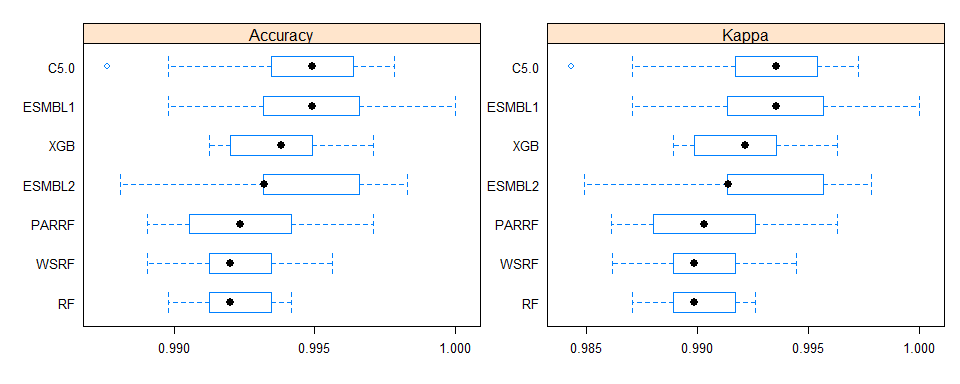

```r
scales <- list(x=list(relation="free"), y=list(relation="free"))
bwplot(comparison, scales=scales)
```

# Results

Given its slighly **superior accuracy (0.99473)** and lower **out of sample error rate (0.00527)**, **ensemble 1** was selected for validation and submission. The following code prepares and executes ensemble 1 model on the validation set and calculates its predictions.

```r
predV.nb    <-  predict(model.nb,valDataCS)
predV.AdaBoost.M1   <-  predict(model.AdaBoost.M1,valDataCS)
predV.gbm   <-  predict(model.gbm,valDataCS)
predV.xgbTree   <-  predict(model.xgbTree,valDataCS)
predV.pls   <-  predict(model.pls,valDataCS)
predV.simpls    <-  predict(model.simpls,valDataCS)
predV.widekernelpls <-  predict(model.widekernelpls,valDataCS)
predV.fda   <-  predict(model.fda,valDataCS)
predV.mda   <-  predict(model.mda,valDataCS)
predV.QdaCov    <-  predict(model.QdaCov,valDataCS)
predV.pda   <-  predict(model.pda,valDataCS)
predV.treebag   <-  predict(model.treebag,valDataCS)
predV.rf    <-  predict(model.rf,valDataCS)
predV.RRF   <-  predict(model.RRF,valDataCS)
predV.wsrf  <-  predict(model.wsrf,valDataCS)
predV.knn   <-  predict(model.knn,valDataCS)
predV.avNNet    <-  predict(model.avNNet,valDataCS)
predV.gcvEarth  <-  predict(model.gcvEarth,valDataCS)
predV.multinom  <-  predict(model.multinom,valDataCS)
predV.C5.0  <-  predict(model.C5.0,valDataCS)
predV.C5.0Tree  <-  predict(model.C5.0Tree,valDataCS)
predV.ctree <-  predict(model.ctree,valDataCS)
predV.rpart <-  predict(model.rpart,valDataCS)

#Combine all predictors into data frame.
pred.DFV <- data.frame(pred.nb = predV.nb,
                       pred.AdaBoost.M1=      predV.AdaBoost.M1,
                       pred.gbm = predV.gbm,
                       pred.xgbTree = predV.xgbTree,
                       pred.pls = predV.pls,
                       pred.simpls = predV.simpls,
                       pred.widekernelpls = predV.widekernelpls,
                       pred.fda = predV.fda,
                       pred.mda = predV.mda,
                       pred.QdaCov = predV.QdaCov,
                       pred.pda = predV.pda,
                       pred.treebag = predV.treebag,
                       pred.rf = predV.rf,
                       pred.RRF = predV.RRF,
                       pred.wsrf = predV.wsrf,
                       pred.knn = predV.knn,
                       pred.avNNet = predV.avNNet,
                       pred.gcvEarth = predV.gcvEarth,
                       pred.multinom = predV.multinom,
                       pred.C5.0 = predV.C5.0,
                       pred.C5.0Tree = predV.C5.0Tree,
                       pred.ctree = predV.ctree,
                       pred.rpart = predV.rpart)

#Calculate predictions
predV.ensemble1 <- predict(model.ensemble1, pred.DFV)
solution <- data.frame(problem_id = valDataCS$problem_id, classe = predV.ensemble1)
```

The predictions are as follows.

```r
solution
```

| problem_id | classe |
| --- | --- |
| 1 | B |
| 2 | A |
| 3 | B |
| 4 | A |
| 5 | A |
| 6 | E |
| 7 | D |
| 8 | B |
| 9 | A |
| 10 | A |
| 11 | B |
| 12 | C |
| 13 | B |
| 14 | A |
| 15 | E |
| 16 | E |
| 17 | A |
| 18 | B |
| 19 | B |
| 20 | B |

# References

1. Velloso, E.; Bulling, A.; Gellersen, H.; Ugulino, W.; Fuks, H. Qualitative Activity Recognition of Weight Lifting Exercises. Proceedings of 4th International Conference in Cooperation with SIGCHI (Augmented Human ’13) . Stuttgart, Germany: ACM SIGCHI, 2013.
2. Aly, M. (2005). Survey on Multiclass Classification Methods. November.
3. Fernandez-Delgado, M., Cernadas, E., & Barro, S. (2014). Do we Need Hundreds of Classifiers to Solve Real World Classification Problems? S˜ao Geraldo: Journal of Machine Learning Research 1.

# Appendix

## Tables

Table 1: Weight Lifting Exercise Dataset Variables

```
##   [1] "X"                        "user_name"
##   [3] "raw_timestamp_part_1"     "raw_timestamp_part_2"
##   [5] "cvtd_timestamp"           "new_window"
##   [7] "num_window"               "roll_belt"
##   [9] "pitch_belt"               "yaw_belt"
##  [11] "total_accel_belt"         "kurtosis_roll_belt"
##  [13] "kurtosis_picth_belt"      "kurtosis_yaw_belt"
##  [15] "skewness_roll_belt"       "skewness_roll_belt.1"
##  [17] "skewness_yaw_belt"        "max_roll_belt"
##  [19] "max_picth_belt"           "max_yaw_belt"
##  [21] "min_roll_belt"            "min_pitch_belt"
##  [23] "min_yaw_belt"             "amplitude_roll_belt"
##  [25] "amplitude_pitch_belt"     "amplitude_yaw_belt"
##  [27] "var_total_accel_belt"     "avg_roll_belt"
##  [29] "stddev_roll_belt"         "var_roll_belt"
```

[output cut: 65 more lines]

Table 3: Selected Predictor Variables

```
##  [1] "roll_belt"            "pitch_belt"           "yaw_belt"
##  [4] "total_accel_belt"     "gyros_belt_x"         "gyros_belt_y"
##  [7] "gyros_belt_z"         "accel_belt_x"         "accel_belt_y"
## [10] "accel_belt_z"         "magnet_belt_x"        "magnet_belt_y"
## [13] "magnet_belt_z"        "roll_arm"             "pitch_arm"
## [16] "yaw_arm"              "total_accel_arm"      "gyros_arm_x"
## [19] "gyros_arm_y"          "gyros_arm_z"          "accel_arm_x"
## [22] "accel_arm_y"          "accel_arm_z"          "magnet_arm_x"
## [25] "magnet_arm_y"         "magnet_arm_z"         "roll_dumbbell"
## [28] "pitch_dumbbell"       "yaw_dumbbell"         "total_accel_dumbbell"
## [31] "gyros_dumbbell_x"     "gyros_dumbbell_y"     "gyros_dumbbell_z"
## [34] "accel_dumbbell_x"     "accel_dumbbell_y"     "accel_dumbbell_z"
## [37] "magnet_dumbbell_x"    "magnet_dumbbell_y"    "magnet_dumbbell_z"
## [40] "roll_forearm"         "pitch_forearm"        "yaw_forearm"
## [43] "total_accel_forearm"  "gyros_forearm_x"      "gyros_forearm_y"
## [46] "gyros_forearm_z"      "accel_forearm_x"      "accel_forearm_y"
## [49] "accel_forearm_z"      "magnet_forearm_x"     "magnet_forearm_y"
## [52] "magnet_forearm_z"     "classe"
```

## Code

Code 1: Code for Training Models

```r
#Setup parallel processing
noCores <- detectCores()-1

##############################################################################
#                           BAYESIAN MODELS                                  #
##############################################################################

#                             NAIVE BAYES                                    #
#Set Seeds
set.seed(1030); seeds <- vector(mode = "list", length = 31)
for(i in 1:30) seeds[[i]]<- sample.int(n=1000, 3)
seeds[[31]]<- sample.int(n=1000, 1)

# Train Control
ctrl <- trainControl(method="repeatedcv", number=10, repeats=3, seeds=seeds)

#Train Model
cl <- makeCluster(noCores); registerDoParallel(cl); print("Running nb model"); print("Running nb model")
model.nb<- train(classe~., data=trainDataCS, trControl=ctrl, method="nb")
stopCluster(cl)
save.image()

##############################################################################
#                           BOOSTING ALGORITHMS                              #
##############################################################################

#                             ADABOOST.M1                                    #
#Set Seeds
set.seed(1030); seeds <- vector(mode = "list", length = 31)
for(i in 1:30) seeds[[i]]<- sample.int(n=1000, 9)
seeds[[31]]<- sample.int(n=1000, 1)

# Train Control
ctrl <- trainControl(method="repeatedcv", number=10, repeats=3, seeds=seeds)

#Train Model
cl <- makeCluster(noCores); registerDoParallel(cl); print("Running AdaBoost.M1 model")
model.AdaBoost.M1<- train(classe~., data=trainDataCS, trControl=ctrl, method="AdaBoost.M1")
stopCluster(cl)
save.image()

#                                   GBM                                     #
#Set Seeds
set.seed(1030); seeds <- vector(mode = "list", length = 31)
for(i in 1:30) seeds[[i]]<- sample.int(n=1000, 9)
seeds[[31]]<- sample.int(n=1000, 1)

# Train Control
ctrl <- trainControl(method="repeatedcv", number=10, repeats=3, seeds=seeds)

#Train Model
cl <- makeCluster(noCores); registerDoParallel(cl); print("Running gbm model")
model.gbm<- train(classe~., data=trainDataCS, trControl=ctrl, method="gbm")
stopCluster(cl)
save.image()

#                                     xgbTree                                         #
#Set Seeds
set.seed(1030); seeds <- vector(mode = "list", length = 31)
for(i in 1:30) seeds[[i]]<- sample.int(n=1000, 12)
seeds[[31]]<- sample.int(n=1000, 1)

# Train Control
ctrl <- trainControl(method="repeatedcv", number=10, repeats=3, seeds=seeds)

#Train Model
cl <- makeCluster(noCores); registerDoParallel(cl); print("Running xgbTree model")
model.xgbTree<- train(classe~., data=trainDataCS, trControl=ctrl, method="xgbTree")
stopCluster(cl)
save.image()


##############################################################################
#                           PARTIAL LEAST SQUARES                            #
##############################################################################

#                      PARTIAL LEAST SQUARES                                #
#Set Seeds
set.seed(1030); seeds <- vector(mode = "list", length = 31)
for(i in 1:30) seeds[[i]]<- sample.int(n=1000, 1)
seeds[[31]]<- sample.int(n=1000, 1)

# Train Control
ctrl <- trainControl(method="repeatedcv", number=10, repeats=3, seeds=seeds)

#Train Model
cl <- makeCluster(noCores); registerDoParallel(cl); print("Running pls model")
model.pls<- train(classe~., data=trainDataCS, trControl=ctrl, method="pls")
stopCluster(cl)
save.image()

#                      PARTIAL LEAST SQUARES (simpls)                        #
#Set Seeds
set.seed(1030); seeds <- vector(mode = "list", length = 31)
for(i in 1:30) seeds[[i]]<- sample.int(n=1000, 1)
seeds[[31]]<- sample.int(n=1000, 1)

# Train Control
ctrl <- trainControl(method="repeatedcv", number=10, repeats=3, seeds=seeds)

#Train Model
cl <- makeCluster(noCores); registerDoParallel(cl); print("Running simpls model")
model.simpls<- train(classe~., data=trainDataCS, trControl=ctrl, method="simpls")
stopCluster(cl)
save.image()

#                               WIDER KERNEL PLS                        #
#Set Seeds
set.seed(1030); seeds <- vector(mode = "list", length = 31)
for(i in 1:30) seeds[[i]]<- sample.int(n=1000, 1)
seeds[[31]]<- sample.int(n=1000, 1)

# Train Control
ctrl <- trainControl(method="repeatedcv", number=10, repeats=3, seeds=seeds)

#Train Model
cl <- makeCluster(noCores); registerDoParallel(cl); print("Running widekernelpls model")
model.widekernelpls<- train(classe~., data=trainDataCS, trControl=ctrl, method="widekernelpls")
stopCluster(cl)
save.image()

##############################################################################
#                           DISCRIMINANT ANALYSIS                            #
##############################################################################
#                         FLEXIBLE DISCRIMINANT ANALYSIS                     #
#Set Seeds
set.seed(1030); seeds <- vector(mode = "list", length = 31)
for(i in 1:30) seeds[[i]]<- sample.int(n=1000, 3)
seeds[[31]]<- sample.int(n=1000, 1)

# Train Control
ctrl <- trainControl(method="repeatedcv", number=10, repeats=3, seeds=seeds)

#Train Model
cl <- makeCluster(noCores); registerDoParallel(cl); print("Running fda model")
model.fda<- train(classe~., data=trainDataCS, trControl=ctrl, method="fda")
stopCluster(cl)
save.image()

#                         MIXTURE DISCRIMINANT ANALYSIS                     #
#Set Seeds
set.seed(1030); seeds <- vector(mode = "list", length = 31)
for(i in 1:30) seeds[[i]]<- sample.int(n=1000, 3)
seeds[[31]]<- sample.int(n=1000, 1)

# Train Control
ctrl <- trainControl(method="repeatedcv", number=10, repeats=3, seeds=seeds)

#Train Model
cl <- makeCluster(noCores); registerDoParallel(cl); print("Running mda model")
model.mda<- train(classe~., data=trainDataCS, trControl=ctrl, method="mda")
stopCluster(cl)
save.image()

#                 ROBUST QUANTILE DISCRIMINANT ANALYSIS                     #
#Set Seeds
set.seed(1030);
# Train Control
ctrl <- trainControl(method="repeatedcv", number=10, repeats=3)
#Train Model
cl <- makeCluster(noCores); registerDoParallel(cl); print("Running QdaCov model")
model.QdaCov<- train(classe~., data=trainDataCS, trControl=ctrl, method="QdaCov")
stopCluster(cl)
save.image()
```

```r
#                         PENALIZED DISCRIMINANT ANALYSIS                     #
#Set Seeds
set.seed(1030); seeds <- vector(mode = "list", length = 31)
for(i in 1:30) seeds[[i]]<- sample.int(n=1000, 3)
seeds[[31]]<- sample.int(n=1000, 1)

# Train Control
ctrl <- trainControl(method="repeatedcv", number=10, repeats=3, seeds=seeds)

#Train Model
cl <- makeCluster(noCores); registerDoParallel(cl); print("Running pda model")
model.pda<- train(classe~., data=trainDataCS, trControl=ctrl, method="pda")
stopCluster(cl)
save.image()

#                         REGULARIZED DISCRIMINANT ANALYSIS                     #
#Set Seeds
set.seed(1030); seeds <- vector(mode = "list", length = 31)
for(i in 1:30) seeds[[i]]<- sample.int(n=1000, 9)
seeds[[31]]<- sample.int(n=1000, 1)

# Train Control
ctrl <- trainControl(method="repeatedcv", number=10, repeats=3, seeds=seeds)

#Train Model
cl <- makeCluster(noCores); registerDoParallel(cl); print("Running rda model")
model.rda<- train(classe~., data=trainDataCS, trControl=ctrl, method="rda")
stopCluster(cl)
save.image()

##############################################################################
#                               BAGGED METHODS                               #
##############################################################################
#                                 TREEBAG                                    #
# Train Control
ctrl <- trainControl(method="repeatedcv", number=10, repeats=3)

#Train Model
cl <- makeCluster(noCores); registerDoParallel(cl); print("Running treebag model")
model.treebag<- train(classe~., data=trainDataCS, trControl=ctrl, method="treebag")
stopCluster(cl)
save.image()

##############################################################################
#                              ENSEMBLE METHODS                              #
##############################################################################
#                             PARALLEL RANDOM FOREST                         #
#Set Seeds
set.seed(1030); seeds <- vector(mode = "list", length = 31)
for(i in 1:30) seeds[[i]]<- sample.int(n=1000, 3)
seeds[[31]]<- sample.int(n=1000, 1)

# Train Control
ctrl <- trainControl(method="repeatedcv", number=10, repeats=3, seeds=seeds)

#Train Model
cl <- makeCluster(noCores); registerDoParallel(cl); print("Running parRF model")
model.parRF<- train(classe~., data=trainDataCS, trControl=ctrl, method="parRF")
stopCluster(cl)
save.image()

#                              RANDOM FOREST                                 #
#Set Seeds
set.seed(1030); seeds <- vector(mode = "list", length = 31)
for(i in 1:30) seeds[[i]]<- sample.int(n=1000, 3)
seeds[[31]]<- sample.int(n=1000, 1)

# Train Control
ctrl <- trainControl(method="repeatedcv", number=10, repeats=3, seeds=seeds)

#Train Model
cl <- makeCluster(noCores); registerDoParallel(cl); print("Running rf model")
model.rf<- train(classe~., data=trainDataCS, trControl=ctrl, method="rf")
stopCluster(cl)
save.image()

#                         REGULARIZED RANDOM FOREST                        #
#Set Seeds
set.seed(1030); seeds <- vector(mode = "list", length = 31)
for(i in 1:30) seeds[[i]]<- sample.int(n=1000, 3)
seeds[[31]]<- sample.int(n=1000, 1)

# Train Control
ctrl <- trainControl(method="repeatedcv", number=10, repeats=3, seeds=seeds)

#Train Model
cl <- makeCluster(noCores); registerDoParallel(cl); print("Running RRF model")
model.RRF<- train(classe~., data=trainDataCS, trControl=ctrl, method="RRF")
stopCluster(cl)
save.image()

#                         WEIGHTED SUBSPACE RANDOM FOREST                        #
#Set Seeds
set.seed(1030); seeds <- vector(mode = "list", length = 31)
for(i in 1:30) seeds[[i]]<- sample.int(n=1000, 3)
seeds[[31]]<- sample.int(n=1000, 1)

# Train Control
ctrl <- trainControl(method="repeatedcv", number=10, repeats=3, seeds=seeds)

#Train Model
cl <- makeCluster(noCores); registerDoParallel(cl); print("Running wsrf model")
model.wsrf<- train(classe~., data=trainDataCS, trControl=ctrl, method="wsrf")
stopCluster(cl)
save.image()

##############################################################################
#                           INSTANCE BASED METHODS                           #
##############################################################################
#                            K NEAREST NEIGHBOR                              #
#Set Seeds
set.seed(1030); seeds <- vector(mode = "list", length = 31)
for(i in 1:30) seeds[[i]]<- sample.int(n=1000, 22)
seeds[[31]]<- sample.int(n=1000, 1)

# Train Control
ctrl <- trainControl(method="repeatedcv", number=10, repeats=3, seeds=seeds)

#Train Model
cl <- makeCluster(noCores); registerDoParallel(cl); print("Running knn model")
model.knn<- train(classe~., data=trainDataCS, trControl=ctrl, method="knn")
stopCluster(cl)
save.image()


##############################################################################
#                              NEURAL NETWORKS                               #
##############################################################################
#                     MODEL AVERAGED NEURAL NETWORK                         #
#Set Seeds
set.seed(1030); seeds <- vector(mode = "list", length = 31)
for(i in 1:30) seeds[[i]]<- sample.int(n=1000, 9)
seeds[[31]]<- sample.int(n=1000, 1)

# Train Control
ctrl <- trainControl(method="repeatedcv", number=10, repeats=3, seeds=seeds)

#Train Model
cl <- makeCluster(noCores); registerDoParallel(cl); print("Running avNNet model")
model.avNNet<- train(classe~., data=trainDataCS, trControl=ctrl, method="avNNet")
stopCluster(cl)
save.image()

#                         Multi-Layer Perceptron                            #
#Set Seeds
set.seed(1030); seeds <- vector(mode = "list", length = 31)
for(i in 1:30) seeds[[i]]<- sample.int(n=1000, 3)
seeds[[31]]<- sample.int(n=1000, 1)

# Train Control
ctrl <- trainControl(method="repeatedcv", number=10, repeats=3, seeds=seeds)

#Train Model
cl <- makeCluster(noCores); registerDoParallel(cl); print("mlp")
model.mlp<- train(classe~., data=trainDataCS, trControl=ctrl, method="mlp")
stopCluster(cl)
save.image()
```

```r
##############################################################################
#           #Multivariate Adaptive Regression Splines (MARS)                 #
##############################################################################
#               Multivariate Adaptive Regression Splines (MARS)              #
#Set Seeds
set.seed(1030); seeds <- vector(mode = "list", length = 31)
for(i in 1:30) seeds[[i]]<- sample.int(n=1000, 1)
seeds[[31]]<- sample.int(n=1000, 1)

# Train Control
ctrl <- trainControl(method="repeatedcv", number=10, repeats=3, seeds=seeds)

#Train Model
cl <- makeCluster(noCores); registerDoParallel(cl); print("Running gcvEarth model")
model.gcvEarth<- train(classe~., data=trainDataCS, trControl=ctrl, method="gcvEarth")
stopCluster(cl)
save.image()

#                     Logistic and Multinomial Regression                    #
#Set Seeds
set.seed(1030); seeds <- vector(mode = "list", length = 31)
for(i in 1:30) seeds[[i]]<- sample.int(n=1000, 3)
seeds[[31]]<- sample.int(n=1000, 1)

# Train Control
ctrl <- trainControl(method="repeatedcv", number=10, repeats=3, seeds=seeds)

#Train Model
cl <- makeCluster(noCores); registerDoParallel(cl); print("Running multinom model")
model.multinom<- train(classe~., data=trainDataCS, trControl=ctrl, method="multinom")
stopCluster(cl)
save.image()

##############################################################################
#                           DECISION BASED METHODS                           #
##############################################################################
#                                     C5.0                                   #
#Set Seeds
set.seed(1030); seeds <- vector(mode = "list", length = 31)
for(i in 1:30) seeds[[i]]<- sample.int(n=1000, 4)
seeds[[31]]<- sample.int(n=1000, 1)

# Train Control
ctrl <- trainControl(method="repeatedcv", number=10, repeats=3, seeds=seeds)

#Train Model
cl <- makeCluster(noCores); registerDoParallel(cl); print("Running C5.0 model")
model.C5.0<- train(classe~., data=trainDataCS, trControl=ctrl, method="C5.0")
stopCluster(cl)
save.image()

#                                     C5.0Tree                              #
#Set Seeds
set.seed(1030); seeds <- vector(mode = "list", length = 31)
for(i in 1:30) seeds[[i]]<- sample.int(n=1000, 3)
seeds[[31]]<- sample.int(n=1000, 1)

# Train Control
ctrl <- trainControl(method="repeatedcv", number=10, repeats=3, seeds=seeds)

#Train Model
cl <- makeCluster(noCores); registerDoParallel(cl); print("Running C5.0Tree model")
model.C5.0Tree<- train(classe~., data=trainDataCS, trControl=ctrl, method="C5.0Tree")
stopCluster(cl)
save.image()

#                                     CTREE                              #
#Set Seeds
set.seed(1030); seeds <- vector(mode = "list", length = 31)
for(i in 1:30) seeds[[i]]<- sample.int(n=1000, 3)
seeds[[31]]<- sample.int(n=1000, 1)

# Train Control
ctrl <- trainControl(method="repeatedcv", number=10, repeats=3, seeds=seeds)

#Train Model
cl <- makeCluster(noCores); registerDoParallel(cl); print("Running ctree model")
model.ctree<- train(classe~., data=trainDataCS, trControl=ctrl, method="ctree")
stopCluster(cl)
save.image()

#                                     J48                                #
#Set Seeds
set.seed(1030); seeds <- vector(mode = "list", length = 31)
for(i in 1:30) seeds[[i]]<- sample.int(n=1000, 3)
seeds[[31]]<- sample.int(n=1000, 1)

# Train Control
ctrl <- trainControl(method="repeatedcv", number=10, repeats=3, seeds=seeds)

#Train Model
cl <- makeCluster(noCores); registerDoParallel(cl); print("Running J48 model")
model.J48<- train(classe~., data=trainDataCS, trControl=ctrl, method="J48")
stopCluster(cl)
save.image()

#                                     JRIP                                #
#Set Seeds
set.seed(1030); seeds <- vector(mode = "list", length = 31)
for(i in 1:30) seeds[[i]]<- sample.int(n=1000, 3)
seeds[[31]]<- sample.int(n=1000, 1)

# Train Control
ctrl <- trainControl(method="repeatedcv", number=10, repeats=3, seeds=seeds)

#Train Model
cl <- makeCluster(noCores); registerDoParallel(cl); print("Running JRip model")
model.JRip<- train(classe~., data=trainDataCS, trControl=ctrl, method="JRip")
stopCluster(cl)
save.image()

#                                     RPART                                #
#Set Seeds
set.seed(1030); seeds <- vector(mode = "list", length = 31)
for(i in 1:30) seeds[[i]]<- sample.int(n=1000, 3)
seeds[[31]]<- sample.int(n=1000, 1)

# Train Control
ctrl <- trainControl(method="repeatedcv", number=10, repeats=3, seeds=seeds)

#Train Model
cl <- makeCluster(noCores); registerDoParallel(cl); print("Running rpart model")
model.rpart<- train(classe~., data=trainDataCS, trControl=ctrl, method="rpart")
stopCluster(cl)
save.image()
```